# Exponential Distribution in R - A research for Statistical inference project (Coursera Data Science Specializacion 2017)

Antonio Marquez Palacios

December 22, 2017

## Synopsis

Normal distribution may be enough to model solutions for many problems in sciences and engineering, but in some special cases there is a need of a different types of density functions, such as the gamma distribution and the exponential distribution.

As part of the Statitical Inferente course from the Data Science Specialization in coursera.org, across this document we will research some of the properties of the latter, exponential distribution, which is a special case of the gamma distribution, and compare with the Central Limit Theorem.

## Simulations

R provides a way to do exponential simulations by calling the rexp(n, rate = 1) function: - n number of observations. If length(n) > 1, the length is taken to be the number required. For this document n = 40 - rate vector of rates (lambda). For this document labmda = 0.2 will be used

Let’s do a single simulation to see how rexp() works:

```r
rexp(40, 0.2)
```

```
##  [1]  6.3964780  1.9147183  1.8574293  3.5038661  1.6586975  2.4466411
##  [7] 17.1543396  5.1240515  3.6401474  0.1963736  1.3471832  4.2859649
## [13]  0.9301560  7.8654866  6.3987645  6.9830303  0.3754124  4.1244524
## [19]  1.6061798  3.1905449  7.6986629  1.0681373  4.1177319  1.1679242
## [25] 15.6937708  4.2037942  4.5459749  6.4722756  4.4985378  1.0390333
## [31]  7.4435702  0.6465190  4.7554474  2.8502949  1.8015235  3.2276966
## [37]  2.8063117  7.5449538  0.8603010  7.1756598
```

It can be seen that 40 values were simulated with a rate of 0.2.

Now, let’s simulate 10000 thousand of exponential distribution samples, for this lets define the following:

```r
library(ggplot2)
n      <- 40
lambda <- 0.2

exponential_simulation <- rexp(n, lambda)
u0    <- mean(exponential_simulation)
sd0   <- sd(exponential_simulation)
var0  <- var(exponential_simulation)
u0
```

```
## [1] 3.725559
```

```r
sd0
```

```
## [1] 3.156496
```

```r
var0
```

```
## [1] 9.963468
```

Now proceed to simulate 10,000 samples:

```r
B      <- 10000
resamples <- matrix(sample(exponential_simulation, n*B, replace = TRUE), B, n)
resampledMeans <- apply(resamples, 1, mean)
```

Check for the sample mean, sample standard deviation and sample variance using the means:

```r
ua    <- mean(resampledMeans)
sda   <- sd(resampledMeans)
vara  <- var(resampledMeans)
ua
```

```
## [1] 3.714938
```

```r
sda
```

```
## [1] 0.4874523
```

```r
vara
```

```
## [1] 0.2376097
```

```r
theoVSsampleDF <- data.frame(u = c(u0,ua), sd=c(sd0, sda), var=c(var0, vara))
theoVSsampleDF
```

| u | sd | var |
| --- | --- | --- |
| 3.725559 | 3.1564961 | 9.9634675 |
| 3.714938 | 0.4874523 | 0.2376097 |

From the table above it can be seen that u0 is of the same order or ua, they look pretty close to each. Standard deviations and Variances differences are big

Plot the samples

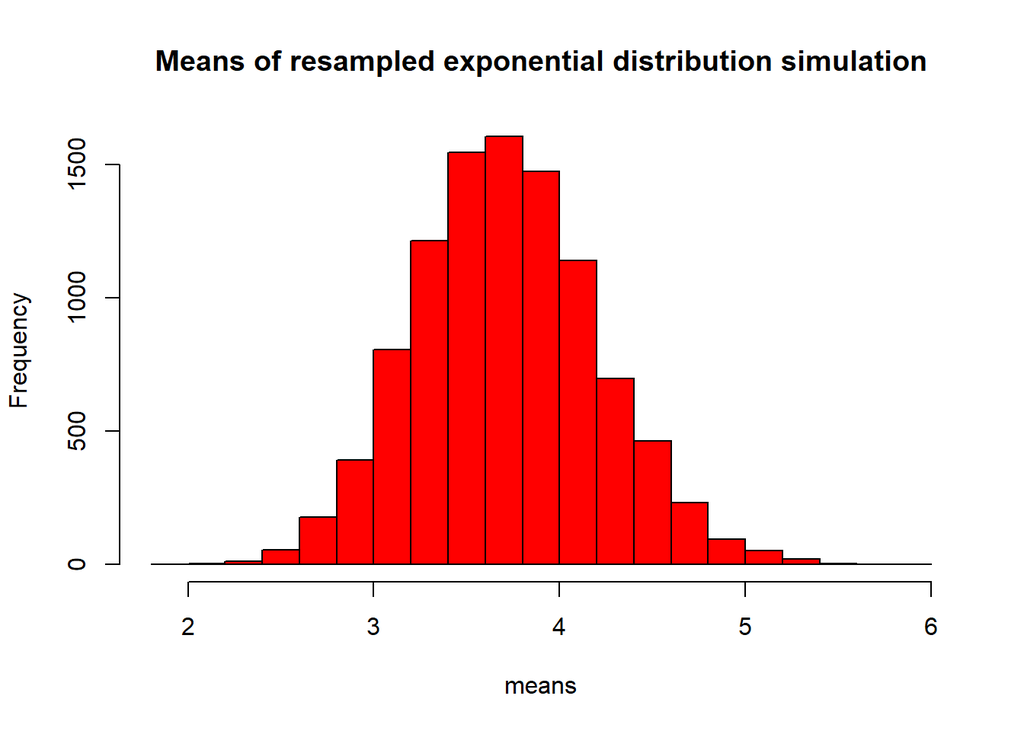

```r
h <- hist(resampledMeans, col="red", xlab="means", main="Means of resampled exponential distribution simulation")
xdnorm <- seq(min(exponential_simulation*10000), max(exponential_simulation*10000), length=1000)
ydnorm <- dnorm(xdnorm, mean=u0*10000, sd=sd0*10000)
ydnorm <- ydnorm * diff(h$mids[1:2])*length(exponential_simulation)
lines(xdnorm, ydnorm, col="black", lwd=2)
```

# Part 2: Basic Inferential Data Analysis for ToothGrowth Data Set: The Effect of Vitamin C on Tooth Growth in Guinea Pigs

The response is the length of odontoblasts (cells responsible for tooth growth) in 60 guinea pigs. Each animal received one of three dose levels of vitamin C (0.5, 1, and 2 mg/day) by one of two delivery methods, (orange juice or ascorbic acid (a form of vitamin C and coded as VC).

To Load the ToothGrowth data set, first import the datasets library

```r
library(datasets)
```

Now let’s proceed with some basic exploratory data analysys. Let’s do a summary:

```r
summary(ToothGrowth)
```

```
##       len        supp         dose
##  Min.   : 4.20   OJ:30   Min.   :0.500
##  1st Qu.:13.07   VC:30   1st Qu.:0.500
##  Median :19.25           Median :1.000
##  Mean   :18.81           Mean   :1.167
##  3rd Qu.:25.27           3rd Qu.:2.000
##  Max.   :33.90           Max.   :2.000
```

From summary it can be seen the following: dose range is [0.5,2.0]. Will use these values for confidence intervals. Note here that values with 1.5 are not present in the dose observations len range is [4.20, 33.90] we know that len is a function of dose and supp len(dose,supp), so let’s see how they relate in a plot:

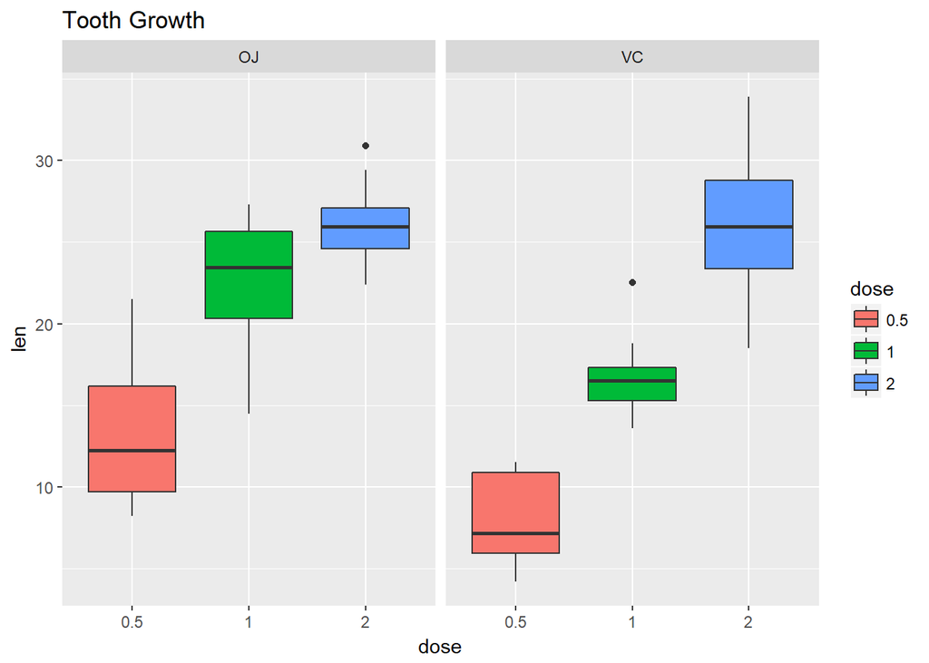

```r
ggplot(ToothGrowth, aes(x=factor(dose), y=len, fill=factor(dose))) + geom_boxplot() + facet_wrap(~supp)+xlab("dose") + ylab("len") + ggtitle("Tooth Growth") + labs(fill="dose")
```

To do the Hypothesis testing, lets assume the following intervals for dose dose = [0.5, 1.0], dose=[1.0, 2.0], dose=[0.5, 2.0]

```r
ToothGrowth_05_10 <- ToothGrowth[ToothGrowth$dose %in% c(0.5,1.0),]
ToothGrowth_10_20 <- ToothGrowth[ToothGrowth$dose %in% c(1.0,2.0),]
ToothGrowth_05_20 <- ToothGrowth[ToothGrowth$dose %in% c(0.5,2.0),]
```

and do the test for each interval:

```r
t.test(data=ToothGrowth_05_10, len ~ dose, paired=FALSE)
```

```
##
##  Welch Two Sample t-test
##
## data:  len by dose
## t = -6.4766, df = 37.986, p-value = 1.268e-07
## alternative hypothesis: true difference in means is not equal to 0
## 95 percent confidence interval:
##  -11.983781  -6.276219
## sample estimates:
## mean in group 0.5   mean in group 1
##            10.605            19.735
```

```r
t.test(data=ToothGrowth_10_20, len ~ dose, paired=FALSE)
```

```
##
##  Welch Two Sample t-test
##
## data:  len by dose
## t = -4.9005, df = 37.101, p-value = 1.906e-05
## alternative hypothesis: true difference in means is not equal to 0
## 95 percent confidence interval:
##  -8.996481 -3.733519
## sample estimates:
## mean in group 1 mean in group 2
##          19.735          26.100
```

```r
t.test(data=ToothGrowth_05_20, len ~ dose, paired=FALSE)
```

```
##
##  Welch Two Sample t-test
##
## data:  len by dose
## t = -11.799, df = 36.883, p-value = 4.398e-14
## alternative hypothesis: true difference in means is not equal to 0
## 95 percent confidence interval:
##  -18.15617 -12.83383
## sample estimates:
## mean in group 0.5   mean in group 2
##            10.605            26.100
```